# Biostat M280 Homework 2

**Due May 11 @ 11:59PM**

## Q1. Nonnegative Matrix Factorization

Nonnegative matrix factorization (NNMF) was introduced by [Lee and Seung (1999)](https://www.nature.com/articles/44565) as an analog of principal components and vector quantization with applications in data compression and clustering. In this homework we consider algorithms for fitting NNMF and (optionally) high performance computing using graphical processing units (GPUs).

[figure not shown]

In mathematical terms, one approximates a data matrix $\mathbf{X} \in \mathbb{R}^{m \times n}$ with nonnegative entries $x_{ij}$ by a product of two low-rank matrices $\mathbf{V} \in \mathbb{R}^{m \times r}$ and $\mathbf{W} \in \mathbb{R}^{r \times n}$ with nonnegative entries $v_{ik}$ and $w_{kj}$. Consider minimization of the squared Frobenius norm $$ L(\mathbf{V}, \mathbf{W}) = \|\mathbf{X} - \mathbf{V} \mathbf{W}\|_{\text{F}}^2 = \sum_i \sum_j \left(x_{ij} - \sum_k v_{ik} w_{kj} \right)^2, \quad v_{ik} \ge 0, w_{kj} \ge 0, $$ which should lead to a good factorization. Later in the course we will learn how to derive a majorization-minimization (MM) algorithm with iterative updates $$ v_{ik}^{(t+1)} = v_{ik}^{(t)} \frac{\sum_j x_{ij} w_{kj}^{(t)}}{\sum_j b_{ij}^{(t)} w_{kj}^{(t)}}, \quad \text{where } b_{ij}^{(t)} = \sum_k v_{ik}^{(t)} w_{kj}^{(t)}, $$ $$ w_{kj}^{(t+1)} = w_{kj}^{(t)} \frac{\sum_i x_{ij} v_{ik}^{(t+1)}}{\sum_i b_{ij}^{(t+1/2)} v_{ik}^{(t+1)}}, \quad \text{where } b_{ij}^{(t+1/2)} = \sum_k v_{ik}^{(t+1)} w_{kj}^{(t)} $$ that drive the objective $L^{(t)} = L(\mathbf{V}^{(t)}, \mathbf{W}^{(t)})$ downhill. Superscript $t$ indicates iteration number. Efficiency (both speed and memory) will be the most important criterion when grading this problem.

1. Implement the algorithm with arguments: $\mathbf{X}$ (data, each row is a vectorized image), rank $r$, convergence tolerance, and optional starting point.

   ```
   function nnmf(
    X::Matrix,
    r::Int;
    maxiter::Int=1000,
    tol::eltype(X)=1e-4,
    V::Matrix{eltype(X)}=rand(size(X, 1), r),
    W::Matrix{eltype(X)}=rand(r, size(X, 2))
    )
    # implementation
    # Output
    return V, W
   end
   ```

2. Database 1 from the [MIT Center for Biological and Computational Learning (CBCL)](http://cbcl.mit.edu) reduces to a matrix $\mathbf{X}$ containing $m = 2,429$ gray-scale face images with $n = 19 \times 19 = 361$ pixels per face. Each image (row) is scaled to have mean and standard deviation 0.25.  
   Read in the [`nnmf-2429-by-361-face.txt`](http://hua-zhou.github.io/teaching/biostatm280-2018spring/hw/hw2/nnmf-2429-by-361-face.txt) file, e.g., using [`readdlm()`](https://docs.julialang.org/en/stable/stdlib/io-network/#Base.DataFmt.readdlm-Tuple{Any,Char,Type,Char}) function, and display a couple sample images, e.g., using ImageView.jl package.
3. Report the run times, using `@time`, of your function for fitting NNMF on the MIT CBCL face data set at ranks $r=10, 20, 30, 40, 50$. For ease of comparison (and grading), please start your algorithm with the provided $\mathbf{V}^{(0)}$ (first $r$ columns of [`V0.txt`](http://hua-zhou.github.io/teaching/biostatm280-2018spring/hw/hw2/V0.txt)) and $\mathbf{W}^{(0)}$ (first $r$ rows of [`W0.txt`](http://hua-zhou.github.io/teaching/biostatm280-2018spring/hw/hw2/W0.txt)) and stopping criterion $$ \frac{|L^{(t+1)} - L^{(t)}|}{|L^{(t)}| + 1} \le 10^{-4}. $$
4. Choose an $r \in \{10, 20, 30, 40, 50\}$ and start your algorithm from a different $\mathbf{V}^{(0)}$ and $\mathbf{W}^{(0)}$. Do you obtain the same objective value and $(\mathbf{V}, \mathbf{W})$? Explain what you find.
5. For the same $r$, start your algorithm from $v_{ik}^{(0)} = w_{kj}^{(0)} = 1$ for all $i,j,k$. Do you obtain the same objective value and $(\mathbf{V}, \mathbf{W})$? Explain what you find.
6. Plot the basis images (rows of $\mathbf{W}$) at rank $r=50$. What do you find?
7. (Optional) Investigate the GPU capabilities of Julia. Report the speed gain of your GPU code over CPU code at ranks $r=10, 20, 30, 40, 50$. Make sure to use the same starting point as in part 2.

```julia
function nnmf(
    X::Matrix{T},
    r::Int;
    maxiter::Int=1000,
    tol::T=1e-4,
    V::Matrix{T}=rand(T, size(X, 1), r),
    W::Matrix{T}=rand(T, r, size(X, 2))
    ) where T <: AbstractFloat
    # implementation
    m = size(X,1)
    n = size(X,2)
    # proallocate. capital letter is for matrix, lowercase "t" means matrix transpose.
    XWt = zeros(m, r)

    WWt = zeros(r, r)
    VWWt = zeros(m, r)

    VtX = zeros(r, n)

    VtVW = zeros(r,n)
    VW = zeros(X)

    l_old = 0.0
    l_new = 0.0

    for iter = 1:maxiter

        V .=
        V .* A_mul_Bt!(XWt, X, W)./ A_mul_B!(VWWt, V, A_mul_Bt!(WWt, W, W))

        W .=
        W .* At_mul_B!(VtX, V, X) ./ A_mul_B!(VtVW, At_mul_B!(WWt, V, V), W)

        VW .= X .- A_mul_B!(VW, V, W)

        l_new = vecnorm(VW)^2

        if abs(l_new - l_old)/(l_old + 1) < tol
            @show iter
            break
        end
        l_old = l_new
    end
    # Output
    return V, W, l_new
end
```

```
nnmf (generic function with 1 method)
```

**(2)**. Display a few images

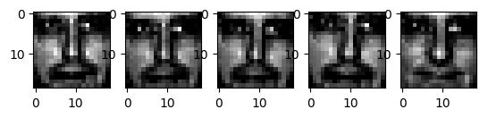

```julia
#Pkg.add("PyPlot")
using PyPlot
imagematrix = readdlm("nnmf-2429-by-361-face.txt");
noimages = 5
for i in 1:noimages
    subplot(1, 5, i)
    PyPlot.imshow(reshape(imagematrix[i, :], 19, 19), cmap = "gray")
end
```

**(3)**. Report running time.

```julia
V0 = readdlm("V0.txt");
W0 = readdlm("W0.txt");

for r in [10 20 30 40 50]
    V = V0[:, 1:r]
    W = W0[1:r,:]
    @time nnmf(imagematrix, r; V = V, W = W)
end
```

```
iter = 239
  1.453749 seconds (307.80 k allocations: 20.662 MiB, 0.46% gc time)
iter = 394
  1.140578 seconds (912 allocations: 7.596 MiB)
iter = 482
  1.923157 seconds (779 allocations: 8.014 MiB)
iter = 581
  2.692661 seconds (782 allocations: 8.445 MiB, 0.33% gc time)
iter = 698
  3.573201 seconds (804 allocations: 8.878 MiB)
```

**(4)** Different starting values

```julia
r = 50
V = V0[:, 1:r]
W = W0[1:r, :]
V1, W1, L1 = nnmf(imagematrix, r; V = V, W = W, maxiter = 1000);
V2, W2, L2 = nnmf(imagematrix, r; maxiter = 1000);
# see if their objective values are the same
@show L1
@show L2
# compare the V and W matrices they returned, by F-norm
@show vecnorm(V1 - V2)
@show vecnorm(W1 - W2)
```

```
iter = 698
iter = 722
L1 = 4430.201581697291
L2 = 4418.623252353646
vecnorm(V1 - V2) = 6.242352491581818
vecnorm(W1 - W2) = 291.85674973749036
```

```
291.85674973749036
```

The two objective values are close, while the decomposition (or V, W matrices) is not exactly the same. The two V matrices are closer than the two W matrices. So with a same (or similar) objective value, the decomposition isn't unique, depending on the starting values used.

**(5)** All-one matrix as starting matrix V and W.

```julia
r = 50
m, n = size(imagematrix)
V = ones(m, r)
W = ones(r, n)

V3, W3, L3 = nnmf(imagematrix, r; V = V, W = W, tol = 1e-4, maxiter = 1000);
@show L3
@show vecnorm(V3*W3 - imagematrix)
```

```
iter = 3
L3 = 25297.01651108185
vecnorm(V3 * W3 - imagematrix) = 159.0503584123024
```

```
159.0503584123024
```

This decomposition is obviously worse than the previous two. The iterative method stopped quickly after the beginning. By printing out the objective values it can be seen that, since the starting point is too far from the optimal decompostion, the objective value is huge from the start. If "going downhill" is slow, the value $\frac{|L^{(t+1)} - L^{(t)}|}{|L^{(t)}| + 1}$ would be tiny and the optimization stopped. I tried commenting out the stopping criteria and running all the 1000 iterations and the objective value is still quite large.

**(6)** Display some base images.

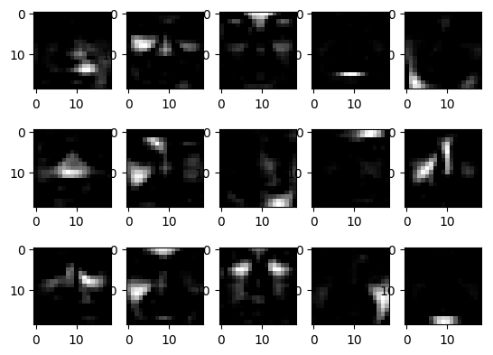

```julia
for i in 1:15
    subplot(3,5,i)
    PyPlot.imshow(reshape(W1[i, :], 19, 19), cmap = "gray")
end
```

These base images look like part of the human face (nose, cheek, etc.)

## Q2. Linear Mixed Models

Consider a linear mixed effects model $$ y_i = \mathbf{x}_i^T \beta + \mathbf{z}_i^T \gamma + \epsilon_i, \quad i=1,\ldots,n, $$ where $\epsilon_i$ are independent normal errors $N(0,\sigma_0^2)$, $\beta \in \mathbb{R}^p$ are fixed effects, and $\gamma \in \mathbb{R}^q$ are random effects assumed to be $N(\mathbf{0}_q, \sigma_1^2 \mathbf{I}_q$) independent of $\epsilon_i$.

1. Show that $$ \mathbf{y} \sim N \left( \mathbf{X} \beta, \sigma_0^2 \mathbf{I}_n + \sigma_1^2 \mathbf{Z} \mathbf{Z}^T \right), $$ where $\mathbf{y} = (y_1, \ldots, y_n)^T \in \mathbb{R}^n$, $\mathbf{X} = (\mathbf{x}_1, \ldots, \mathbf{x}_n)^T \in \mathbb{R}^{n \times p}$, and $\mathbf{Z} = (\mathbf{z}_1, \ldots, \mathbf{z}_n)^T \in \mathbb{R}^{n \times q}$.
2. Write a function, with interface

   ```
   logpdf_mvn(y::Vector, Z::Matrix, σ0::Number, σ1::Number),
   ```

   that evaluates the log-density of a multivariate normal with mean $\mathbf{0}$ and covariance $\sigma_0^2 \mathbf{I} + \sigma_1^2 \mathbf{Z} \mathbf{Z}^T$ at $\mathbf{y}$. Make your code efficient in the $n \gg q$ case.
3. Compare your result (both accuracy and timing) to the [Distributions.jl](http://distributionsjl.readthedocs.io/en/latest/multivariate.html#multivariate-normal-distribution) package using following data.

   ```
   using BenchmarkTools, Distributions

    srand(280)
    n, q = 2000, 10
    Z = randn(n, q)
    σ0, σ1 = 0.5, 2.0
    Σ = σ1^2 * Z * Z.' + σ0^2 * I
    mvn = MvNormal(Σ) # MVN(0, Σ)
    y = rand(mvn) # generate one instance from MNV(0, Σ)

    # check you answer matches that from Distributions.jl
    @show logpdf_mvn(y, Z, σ0, σ1)
    @show logpdf(mvn, y)

    # benchmark
    @benchmark logpdf_mvn(y, Z, σ0, σ1)
    @benchmark logpdf(mvn, y)
   ```

**(1)** In matrix notation $$ \mathbf{y} = \mathbf{X} \beta + \mathbf{Z} \gamma + E, $$ Where $\varepsilon = (\epsilon_1, \ldots, \epsilon_n)^T, E \sim MVN(0,\sigma_0^2I_n)$. Since \gamma and E are independent normal-distributed random variables, and $\mathbf{X}$ and $\mathbf{Z}$ are known/fixed, $\mathbf{y}$ also follows normal distribution. And,

$$ E(\mathbf{y}) = E(\mathbf{X} \beta) + E(\mathbf{Z} \gamma) + E(\varepsilon) = \mathbf{X} \beta + \mathbf{Z} E(\gamma) + E(\varepsilon) = \mathbf{X} \beta + \mathbf{0} + \mathbf{0} = \mathbf{X} \beta $$

$$ Var(\mathbf{y}) = Var(\mathbf{Z} \gamma) + Var(\varepsilon) = \mathbf{Z} Var(\gamma) \mathbf{Z}^T + Var(\varepsilon)= \sigma_1^2 \mathbf{Z} \mathbf{Z}^T + \sigma_0^2 \mathbf{I}_n $$

So $$ \mathbf{y} \sim N \left( \mathbf{X} \beta, \sigma_0^2 \mathbf{I}_n + \sigma_1^2 \mathbf{Z} \mathbf{Z}^T \right), $$

```julia
function logpdf_mvn(y::Vector, Z::Matrix, σ0::Number, σ1::Number)
    n = length(y)
    zchol = cholfact(I + σ1^2 / σ0^2 * Symmetric(Z' * Z))
    logdetzchol = 2 * n * log(σ0) + logdet(zchol)
    y2 = (Z'y) * (σ1 / σ0^2)

    - (n / 2) * log(2π) - (1 / 2) * logdetzchol -
    (1 / 2) * (dot(y, y) / σ0^2 - sum(abs2, zchol[:L] \ (y2)))

end
```

```
logpdf_mvn (generic function with 1 method)
```

```julia
using BenchmarkTools, Distributions

 srand(280)
 n, q = 2000, 10
 Z = randn(n, q)
 σ0, σ1 = 0.5, 2.0
 Σ = σ1^2 .* Symmetric(Z * Z') + σ0^2 * I
 mvn = MvNormal(Σ) # MVN(0, Σ)
 y = rand(mvn)

 @show logpdf_mvn(y, Z, σ0, σ1)
 @show logpdf(mvn, y)
```

```
logpdf_mvn(y, Z, σ0, σ1) = -1571.573673465511
logpdf(mvn, y) = -1571.573673465414
```

```
-1571.573673465414
```

The results are the same (accuracy checked).

```julia
# benchmark
 @benchmark logpdf_mvn(y, Z, σ0, σ1)
```

```
BenchmarkTools.Trial:
  memory estimate:  5.11 KiB
  allocs estimate:  19
  --------------
  minimum time:     21.786 μs (0.00% GC)
  median time:      22.319 μs (0.00% GC)
  mean time:        23.726 μs (1.55% GC)
  maximum time:     1.961 ms (95.40% GC)
  --------------
  samples:          10000
  evals/sample:     1
```

```julia
@benchmark logpdf(mvn, y)
```

```
BenchmarkTools.Trial:
  memory estimate:  15.78 KiB
  allocs estimate:  3
  --------------
  minimum time:     4.146 ms (0.00% GC)
  median time:      4.871 ms (0.00% GC)
  mean time:        4.908 ms (0.00% GC)
  maximum time:     7.274 ms (0.00% GC)
  --------------
  samples:          1015
  evals/sample:     1
```

The logpdf_mvn is more efficient that logpdf, efficiency checked.